# Data Science for Public Policy

Assignment 04: Data Visualization, Quarto, and Git

Author

Juliette Taylor - jmt333, Thomas Tiberghien Alvarez - tt791

The goal of this analysis is to generate visualizations regarding the usage of the Capital Bikeshare (CaBi) system in Washington DC and draw some conclusions that can be useful in generating policy changes. The data comes from CaBi’s own [System data](https://ride.capitalbikeshare.com/system-data).

### Setup

```r
library(tidyverse)
library(knitr)
library(lubridate)
library(purrr)
library(stringr)
library(scales)
library(tigris)
library(sf)
```

The function below is used to download the data zip files into csvs that are then ingested by R. Make sure that the period input is equivalent to the ones listed in the Capital Bikeshare [downloadable files](https://s3.amazonaws.com/capitalbikeshare-data/index.html)

```r
#' Load cabi data
#'
#' @param period The period of time to load data for, as a string. Should match the zip files in the cabi website
#' @param zip_dir The directory into which zip files will be downloaded. Should be created before running the function
#' @param csv_dir The directory into which csv files will be generated. Should be created before running the function
#'
#' @return A tibble with all of the data downloaded from the CaBi website for that period
#' @examples load_cabi_data("2014")
load_cabi_data <- function(period, zip_dir = "data/", csv_dir = "csvs/") {
        url <- str_glue("https://s3.amazonaws.com/capitalbikeshare-data/{period}-capitalbikeshare-tripdata.zip")
        download.file(url, destfile = str_glue(paste0(zip_dir,"{period}-cabi-tripdata.zip")))
        Sys.sleep(0.5)
        zip_files <- paste0(zip_dir, list.files(zip_dir))
        for (x in zip_files) {
                unzip(x, exdir = csv_dir)
        }
        csv_files <- paste0(csv_dir, list.files(csv_dir, pattern = ".csv"))
        output <- bind_rows(map(csv_files, read_csv)) %>% janitor::clean_names()
        unlink(paste0(zip_dir,"*"), recursive = TRUE)
        unlink(paste0(csv_dir,"*"), recursive = TRUE)
        return(output)
}
```

# Plot 1: Ridership changes

The goal of this plot is to simply see how ridership has changed throughout the years since Capital Bikeshare got started.

### Obtaining the data

The challenge with this was to standardize the way in which the data came in, since different periods have different ways to save the data in the zip files. The main difference was that starting in 2018, the data is saved by month instead of by year.

```r
#' Total monthly rides for years prior to 2018
#'
#' @param year The year as an int or double, for which monthly aggregate data needs to be obtained
#'
#' @return A tibble grouped by month of total monthly rides, with additional columns for the year and the period
#' @examples monthly_rides_pre2018(2012)
monthly_rides_pre2018 <- function(year) {
        output <- load_cabi_data(as.character(year)) %>%
                group_by(month = month(start_date)) %>%
                summarise(counts = n()) %>%
                ungroup() %>%
                mutate(year = year,
                       str_month = str_pad(month, 2, pad = "0")) %>%
                mutate(period = paste0(year, str_month)) %>%
                select(year, month, counts, period)
        return(output)
}
```

```r
#' Total monthly rides for years starting 2018
#'
#' @param year The year as an int or double, for which monthly aggregate data needs to be obtained
#' @param month Optional list of months to use, since some years (namely 2022) are not yet complete
#'
#' @return A tibble grouped by month of total monthly rides, with additional columns for the year and the period
#' @example monthly_rides_post2018(2022, month = 1:9)
monthly_rides_post2018 <- function(year, month = 1:12) {
        monthly_data <- tibble(year = year, month = month, counts = integer(1)) %>%
                mutate(str_month = str_pad(month, 2, pad = "0")) %>%
                mutate(period = paste0(year, str_month)) %>%
                select(-str_month)
        for (i in monthly_data$period) {
                data <- load_cabi_data(i)
                monthly_data <- monthly_data %>%
                        mutate(counts = if_else(period == i, nrow(data), counts))
        }
        return(monthly_data)
}
```

### Putting the data together

The code below uses the previous functions to generate data for corresponding periods and then aggregates them together to get a single tibble with data from 2010 to 2022

```r
monthly_2010_2017 <- bind_rows(map(2010:2017, monthly_rides_pre2018))
monthly_2018_2021 <- bind_rows(map(2018:2021, monthly_rides_post2018))
monthly_2022 <- monthly_rides_post2018(2022, month = 1:9)

monthly_data <- bind_rows(monthly_2010_2017, monthly_2018_2021, monthly_2022)
```

The code below generates a monthly average by year in order to see the yearly trends more easily in the final plot

```r
monthly_average_by_year <- monthly_data %>%
        group_by(year) %>%
        summarise(avg = mean(counts)) %>%
        ungroup()
```

### Generating the plot

The code below generates the final plot

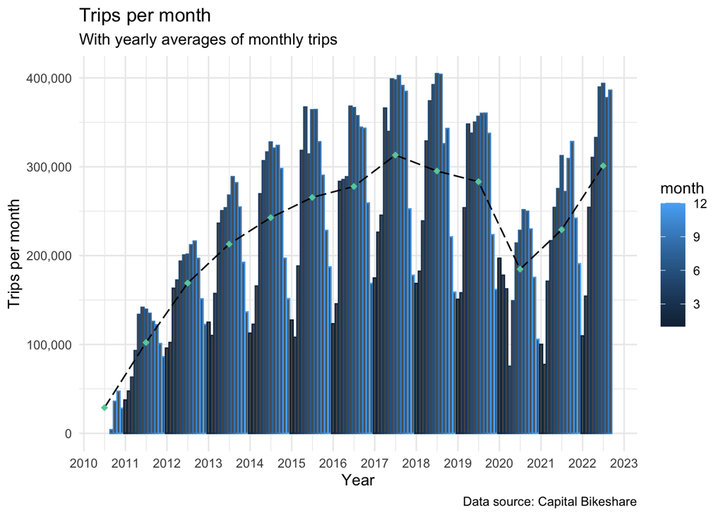

```r
ggplot() +
        geom_col(data = monthly_data, mapping = aes(x=ym(period), y=counts, colour = month)) +
        geom_line(data = monthly_average_by_year,
                  mapping = aes(x = ym(paste0(year,"07")), y = avg), linetype = 5) +
        geom_point(data = monthly_average_by_year,
                  mapping = aes(x = ym(paste0(year,"07")), y = avg),
                  shape = 18,
                  size = 2,
                  colour = "aquamarine3") +
        theme_minimal() +
        xlab("Year") + ylab("Trips per month") +
        scale_y_continuous(labels = comma) +
        scale_x_date(date_breaks = "1 year", date_labels = "%Y") +
        labs(title = "Trips per month",
             subtitle = "With yearly averages of monthly trips",
             caption = "Data source: Capital Bikeshare")
```

### Interpretation

On first impression, the plot shows some trends that are obvious, such as telling us that the winters will have fewer rides, or that ridership has increased since 2010, when there were likely fewer stations and bikes to go around, and residents of Washington did not know about the availability of the Capital Bikeshare program. We can also see the dip in ridership in 2020 as Covid hit and people started staying inside more. Something that is surprising though, is that peak ridership was actually in 2017.

# Plot 2: Ridership throughout the day

The goal of this plot is to see peak and trough ridership times during an average day.

### Obtaining the data

Here we used September 2022 data to count the number of rides for each start time over 24 hours.

```r
data_sept_2022 <- load_cabi_data("202209") %>% janitor::clean_names()

minutes <- data_sept_2022 %>%
        group_by(hour = hour(started_at), minute = minute(started_at)) %>%
        summarise(count = n()) %>%
        ungroup() %>%
        mutate(hour_minute = 60*hour+minute)
```

### Generating the plot

The code below generates the final plot.

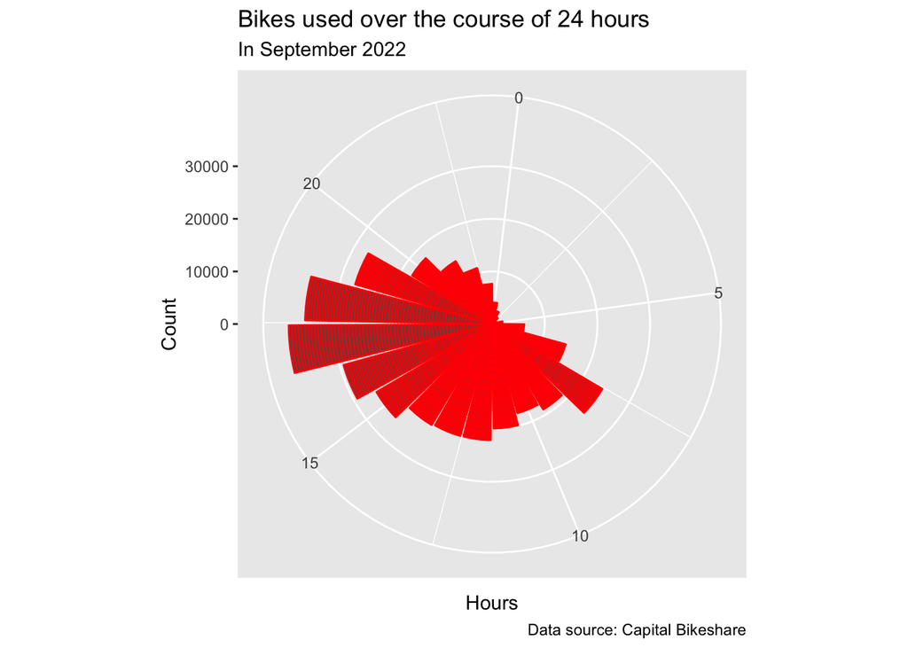

```r
ggplot(data = minutes) +
        geom_col(mapping = aes(x = hour, y = count),
                 colour = "red") +
        coord_polar() +
        labs(x= "Hours", y= "Count",
             title = "Bikes used over the course of 24 hours",
             subtitle = "In September 2022",
             caption = "Data source: Capital Bikeshare")
```

### Intepretation

This graph is relatively unsurprising in highlighting very low usage of bikes during the night, meaning between 10pm and 7am. Bike usage picks up considerably circa 7am, corresponding to human flows to work places or places of study. Usage then remains quite steady throughout the day until around 4pm when it starts to pick up significantly for rush hour. Peak times are without a doubt between 4pm and 7pm. Implications for policy may be ensuring any daily bike maintenance happens before these times.

# Plot 3: User types

The goal of this plot is to find how the type of user differs geographically throughout the city. In order to do this, we use the start station location and compare it with a map of Washington DC, colouring it based on which type of user uses it most. This analysis uses the data from August 2022.

### Obtaining the data

We need 2 different datasets here: one for the aggregated data by station, and one that has the geospatial data for DC.

```r
station_data <- load_cabi_data("202208") %>%
        filter(!is.na(start_station_id)) %>%
        group_by(station_id = start_station_id) %>%
        summarise(num_member = sum(member_casual == "member"),
                  num_casual = sum(member_casual == "casual"),
                  station_name = first(start_station_name),
                  lat = first(start_lat),
                  long = first(start_lng)) %>%
        ungroup() %>%
        mutate(more_user_type = if_else(num_member > num_casual, "member", "casual")) %>%
        st_as_sf(coords = c("long", "lat"), crs = "EPSG:4269")

dc_map <- states(cb = TRUE, progress_bar = FALSE) %>%
        filter(STUSPS == "DC")
```

### Generating the plot

The code below generates the final plot

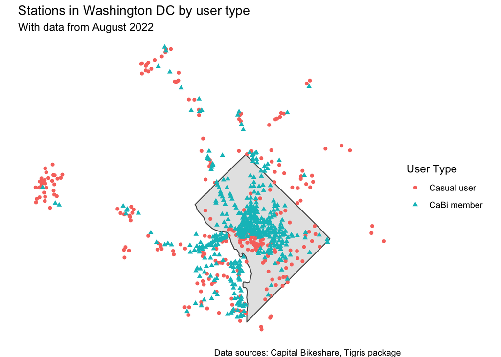

```r
ggplot() +
        geom_sf(data = dc_map) +
        geom_sf(data = station_data,
                mapping = aes(colour = more_user_type, shape = more_user_type),
                size = 1.5) +
        theme_void() +
        scale_shape_discrete(name = "User Type",
                              breaks = c("casual", "member"),
                              labels = c("Casual user", "CaBi member")) +
        scale_colour_discrete(name = "User Type",
                              breaks = c("casual", "member"),
                              labels = c("Casual user", "CaBi member")) +
        labs(title = "Stations in Washington DC by user type",
             subtitle = "With data from August 2022",
             caption = "Data sources: Capital Bikeshare, Tigris package")
```

### Interpretation

What is interesting about this plot is that member users, the ones who have a subscription to Capital Bikeshares and don’t just pick up bikes on demand, make up the bulk of users in the downtown areas. It is only on the peripheries that casual users make up the majority of users. Maybe this has to do with how long the stations have been there. As CaBi expands outward, it takes a while for users to start using the bikes more consistently and seeing the value of getting a membership. Further analysis could also be done to see how often tourists use this service. If they are casual members then the downtown areas should see a few more casual-dominated stations, and this does seem to be the case around the Mall.

# Plot 4: Station usage

The idea of this plot was to understand which stations are used the most across the city.

### Obtaining the data

To obtain the data it was important to filter out for NA, which accounted for the largest total rides. Stations were then sorted in descending order and the top 10 most used stations were selected.

```r
#data_sept_2022 <- load_cabi_data("202209") %>% janitor::clean_names()
station_counts <- data_sept_2022 %>%
  filter(!is.na(start_station_id)) %>%
  group_by(station_id = start_station_id) %>%
  summarise(count = n()) %>%
  arrange(desc(count)) %>%
  slice(1:10) %>%
  ungroup()

top_ten <- station_counts$station_id
plot_data <- data_sept_2022 %>%
  filter(start_station_id == top_ten)
```

### Generating the plot

The code below generates the final plot.

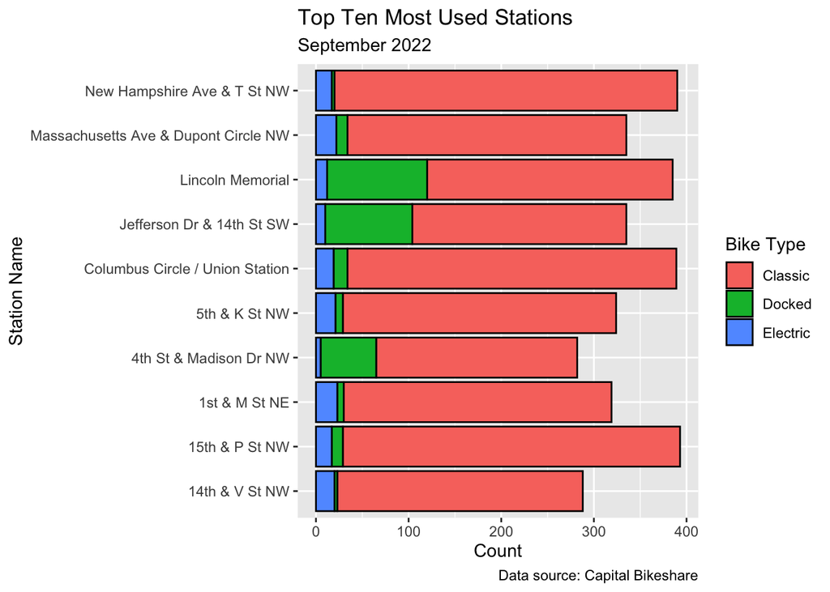

```r
ggplot(data = plot_data) +
  geom_bar(mapping = aes(y=start_station_name, fill=rideable_type),
           colour = "black") +
   scale_fill_discrete(name = "Bike Type",
                              breaks = c("classic_bike", "docked_bike", "electric_bike"),
                              labels = c("Classic", "Docked", "Electric")) +
  xlab("Count") + ylab("Station Name") +
  labs(title = "Top Ten Most Used Stations",
       subtitle = "September 2022",
       caption = "Data source: Capital Bikeshare")
```

### Interpretation

Unsurprisingly, the top Capital Bikeshare stations correspond to areas of strategic importance in DC - transport hubs (Union Station), retail streets (M St), office buildings (Dupont Circle), and entertainment areas (14th St). It would be worth investigating whether these stations are consistently empty, in which case it might be worthwhile to add bikes to these particular locations. Interestingly, before filtering, the top station was NA with 12,950 counts. This, along with the lack of clarity around the meaning of docked bikes, poses questions about Capital Bikeshare’s data set.